## MU

The key concept of MI is to use the distribution of the observed data to estimate a set of plausible values for the missing data. Royston

-> Unbiased + Effizient

MICE: FCS oder Sequential Regression Multivariate Imputation

Prädiktoren der unvollständigen Variablen einbezogen (Auxiliarvariablen): - Reduce bias, make MAR more plausible - Improve imputations, reduce variance

the imputation model should include every variable that both predicts the incomplete variable and predicts whether the incomplete variable is missing.

Thus, justification of the MICE procedure has rested on empirical studies [10, 49] rather than theoretical arguments.

MI, like all missing data procedures that are based around an MAR assumption, is sensitive to departures from MAR, especially with larger fractions of missing data. One way to deal with this is to include many variables in the imputation model in an effort to make MAR more plausible. This approach is well suited to MI since a complex imputation model can be built without affecting the choice of analysis model: for example, post-randomization variables can be included when imputing missing outcomes in a clinical trial, but not included in the analysis model

In principle, a rich imputation structure is desirable, but in practice, fitting such a complex set of imputation models may defeat the software or lead to model instability. For example, we have found it particularly challenging to work with structures including several nominal categorical variables imputed by multinomial logistic regression; convergence of such large models is an issue, tending to make the imputation process unacceptably slow.

It is hard to propose universal solutions, but careful exploration of the data may suggest smaller imputation models that are unlikely to lead to substantial bias. In general, one should try to simplify the imputation structure without damaging it; for example, omit variables that seem on exploratory investigation unlikely to be required in ‘reasonable’ analysis models, but avoid omitting variables that are in the analysis model or variables that clearly contribute towards satisfying the MAR assumption.

## Rubin’s Rules

$$\begin{align*}
\openup 3\jot
\begin{split}
T & = \overbrace{ \left(\frac{1}{m}\sum^{m}_{\ell=1}\bar{U}_\ell\right)}^{\bar{U}} + \left(1+\frac{1}{m}\right) \overbrace{ \left(\frac{1}{m-1}\sum_{\ell=1}^m (\hat Q_\ell-\bar Q)(\hat Q_\ell-\bar Q)'\right)}^{B} \\
& = \bar{U} + \left(1+\frac{1}{m}\right)B \\
& \Rightarrow \bar{U} + B ~~~~~\text{as}~~~~~m \rightarrow \infty
\end{split}
\end{align*}$$

## Second Frame

### Bulleted Lists

- Element A
- Element B
  - B.1
  - B.2
- Element C

# Elements

## Typography

```
The theme provides sensible defaults to
\emph{emphasize} text, \alert{accent} parts
or show \textbf{bold} results.

In Markdown, you can also use _emphasize_ and **bold**.
```

.

In Markdown, you can also use *emphasize* and **bold**.

## Math

$$\begin{equation*}
e = \lim_{n\to \infty} \left(1 + \frac{1}{n}\right)^n
\end{equation*}$$

## R Figure Example

The following code generates the plot on the next slide (taken from `help(bxp)` and modified slightly):

```r
library(stats)
set.seed(753)
bx.p <- boxplot(split(rt(100, 4),
                      gl(5, 20)), plot=FALSE)
bxp(bx.p, notch = FALSE, boxfill = "lightblue",
    frame = FALSE, outl = TRUE,
    main = "Example from help(bxp)")
```

## R Figure Example

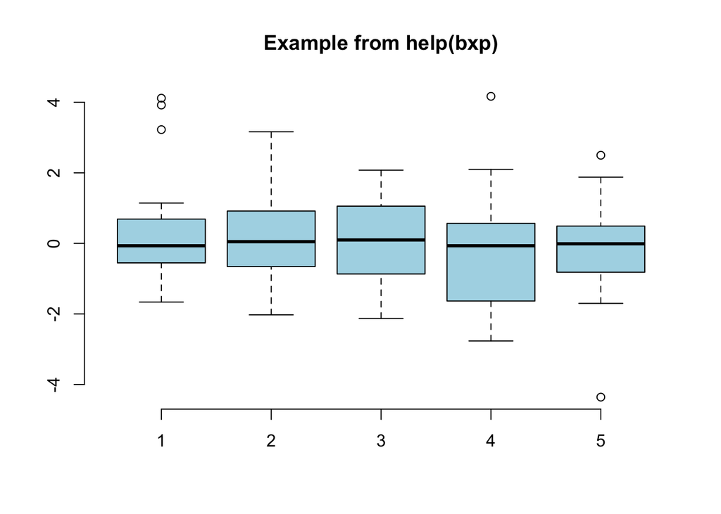

## R Table Example

A simple `knitr::kable` example:

```r
knitr::kable(mtcars[1:5, 1:8],
             caption="(Parts of) the mtcars dataset")
```

(Parts of) the mtcars dataset

|  | mpg | cyl | disp | hp | drat | wt | qsec | vs |
| --- | --- | --- | --- | --- | --- | --- | --- | --- |
| Mazda RX4 | 21.0 | 6 | 160 | 110 | 3.90 | 2.620 | 16.46 | 0 |
| Mazda RX4 Wag | 21.0 | 6 | 160 | 110 | 3.90 | 2.875 | 17.02 | 0 |
| Datsun 710 | 22.8 | 4 | 108 | 93 | 3.85 | 2.320 | 18.61 | 1 |
| Hornet 4 Drive | 21.4 | 6 | 258 | 110 | 3.08 | 3.215 | 19.44 | 1 |
| Hornet Sportabout | 18.7 | 8 | 360 | 175 | 3.15 | 3.440 | 17.02 | 0 |

# n

What probability distribution is appropriate? The answer determines the random component of the model. The choice of probability distribution may be suggested by the response data (for example, proportions of a total suggest a binomial distribution), or knowledge of how the variance changes with the mean.

How are the explanatory variables related to the mean of the response μ? The answer suggests the systematic component of the model. Glms assume a function linking the linear predictor to the mean, such as log mu = eta for example. That is, glms are regression models linear in the parameters.

## n

Glms assume the responses come from a distribution that belongs to a fam- ily of distributions called the exponential dispersion model family (or edm family, or just edms). Continuous edms include the normal and gamma dis- tributions. Discrete edms include the Poisson, binomial and negative bino- mial distributions.

## n

[figure not shown]

## n

Linear Predictor

$$\eta_i = (o_i) +\alpha + \mathbf{x}_i^\top\mathbf{\beta}$$

Kopplungsfunktion (link function):

$$g(\mu) = \eta$$

Offset (bekannte “Exposure”):

$$\begin{align*}
\begin{split}
g(\mu) &= \log(\mu) = \eta \\
&= \log\left(\frac{\mu}{E}\right) = \eta \\
&= \log(\mu) = \eta + \log(E)
\end{split}
\end{align*}$$

## Resources

### For more information:

- See the [Metropolis repository](https://github.com/matze/mtheme) for more on Metropolis
- See the [RMarkdown repository](https://github.com/rstudio/rmarkdown) for more on RMarkdown
- See the [binb repository](https://github.com/eddelbuettel/binb) for more on binb
- See the [binb vignettes](https://github.com/eddelbuettel/binb/vignettes) for more examples.